# Bayesian GLMM Part6

Author

Murray Logan

Published

09/09/2025

# 1 Preparations

Load the necessary libraries

```r
library(tidyverse) # for data wrangling
library(car) # for regression diagnostics
library(broom) # for tidy output
library(ggfortify) # for model diagnostics
library(knitr) # for kable
library(emmeans) # for estimating marginal means
library(MASS) # for glm.nb
library(brms)
library(broom.mixed)
library(tidybayes)
library(bayesplot)
library(standist) # for visualizing distributions
library(rstanarm)
library(cmdstanr) # for cmdstan
library(ggeffects)
library(rstan)
library(DHARMa)
library(ggridges)
library(easystats) # framework for stats, modelling and visualisation
library(patchwork)
library(modelsummary)
source("helperFunctions.R")
```

# 2 Scenario

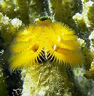

**Figure** 1: fanworms

In an attempt to understand the effects on marine animals of short-term exposure to toxic substances, such as might occur following a spill, or a major increase in storm water flows, a it was decided to examine the toxicant in question, Copper, as part of a field experiment in Hong Kong. The experiment consisted of small sources of Cu (small, hemispherical plaster blocks, impregnated with copper), which released the metal into sea water over 4 or 5 days. The organism whose response to Cu was being measured was a small, polychaete worm, Hydroides, that attaches to hard surfaces in the sea, and is one of the first species to colonize any surface that is submerged. The biological questions focused on whether the timing of exposure to Cu affects the overall abundance of these worms. The time period of interest was the first or second week after a surface being available.

The experimental setup consisted of sheets of black perspex (settlement plates), which provided good surfaces for these worms. Each plate had a plaster block bolted to its centre, and the dissolving block would create a gradient of [Cu] across the plate. Over the two weeks of the experiment, a given plate would have plain plaster blocks (Control) or a block containing copper in the first week, followed by a plain block, or a plain block in the first week, followed by a dose of copper in the second week. After two weeks in the water, plates were removed and counted back in the laboratory. Without a clear idea of how sensitive these worms are to copper, an effect of the treatments might show up as an overall difference in the density of worms across a plate, or it could show up as a gradient in abundance across the plate, with a different gradient in different treatments. Therefore, on each plate, the density of worms (#/cm<sup>2</sup>) was recorded at each of four distances from the center of the plate.

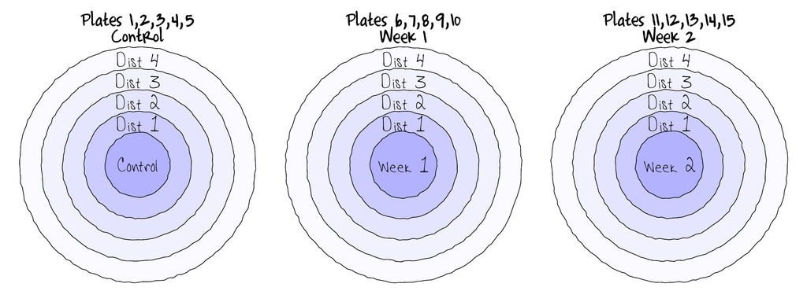

**Table** 1: Format of copper.csv data file

| COPPER | PLATE | DIST | WORMS |
| --- | --- | --- | --- |
| control | 200 | 4 | 11.50 |
| control | 200 | 3 | 13.00 |
| .. | .. | .. | .. |

**Table** 2: Description of the variables in the copper data file

| **COPPER** | Categorical listing of the copper treatment (control = no copper applied, week 2 = copper treatment applied in second week and week 1= copper treatment applied in first week) applied to whole plates. … |
| --- | --- |
| **PLATE** | Substrate provided for polychaete worm colonization on which copper treatment applied. These are the plots (Factor B). Numbers in this column represent numerical labels given to each plate. |
| **DIST** | Categorical listing for the four concentric distances from the center of the plate (source of copper treatment) with 1 being the closest and 4 the furthest. Factor C (within plot factor) |
| **WORMS** | Density (#/cm<sub>2</sub>) of worms measured. Response variable. |

# 3 Read in the data

```r
copper <- read_csv("../data/copper.csv", trim_ws = TRUE)
```

**glimpse**

```r
glimpse(copper)
```

```
Rows: 60
Columns: 4
$ COPPER <chr> "control", "control", "control", "control", "control", "control…
$ PLATE  <dbl> 200, 200, 200, 200, 39, 39, 39, 39, 34, 34, 34, 34, 36, 36, 36,…
$ DIST   <dbl> 4, 3, 2, 1, 4, 3, 2, 1, 4, 3, 2, 1, 4, 3, 2, 1, 4, 3, 2, 1, 4, …
$ WORMS  <dbl> 11.50, 13.00, 13.50, 12.00, 17.75, 13.75, 12.75, 12.50, 11.50, …
```

**head**

```r
## Explore the first 6 rows of the data
head(copper)
```

```
# A tibble: 6 × 4
  COPPER  PLATE  DIST WORMS
  <chr>   <dbl> <dbl> <dbl>
1 control   200     4  11.5
2 control   200     3  13
3 control   200     2  13.5
4 control   200     1  12
5 control    39     4  17.8
6 control    39     3  13.8
```

**str**

```r
str(copper)
```

```
spc_tbl_ [60 × 4] (S3: spec_tbl_df/tbl_df/tbl/data.frame)
 $ COPPER: chr [1:60] "control" "control" "control" "control" ...
 $ PLATE : num [1:60] 200 200 200 200 39 39 39 39 34 34 ...
 $ DIST  : num [1:60] 4 3 2 1 4 3 2 1 4 3 ...
 $ WORMS : num [1:60] 11.5 13 13.5 12 17.8 ...
 - attr(*, "spec")=
  .. cols(
  ..   COPPER = col_character(),
  ..   PLATE = col_double(),
  ..   DIST = col_double(),
  ..   WORMS = col_double()
  .. )
 - attr(*, "problems")=<externalptr>
```

**Easystats (datawizard)**

```r
copper |> datawizard::data_codebook()
```

```
copper (60 rows and 4 variables, 4 shown)

ID | Name   | Type      | Missings |     Values |          N
---+--------+-----------+----------+------------+-----------
1  | COPPER | character | 0 (0.0%) |    control | 20 (33.3%)
   |        |           |          |     Week 1 | 20 (33.3%)
   |        |           |          |     Week 2 | 20 (33.3%)
---+--------+-----------+----------+------------+-----------
2  | PLATE  | numeric   | 0 (0.0%) |  [12, 204] |         60
---+--------+-----------+----------+------------+-----------
3  | DIST   | numeric   | 0 (0.0%) |          1 | 15 (25.0%)
   |        |           |          |          2 | 15 (25.0%)
   |        |           |          |          3 | 15 (25.0%)
   |        |           |          |          4 | 15 (25.0%)
---+--------+-----------+----------+------------+-----------
4  | WORMS  | numeric   | 0 (0.0%) | [0, 17.75] |         60
------------------------------------------------------------
```

**Skim (modelsummary)**

Unique

Missing Pct.

Mean

SD

Min

Median

Max

Histogram

PLATE

15

0

98.7

77.0

12.0

61.0

204.0

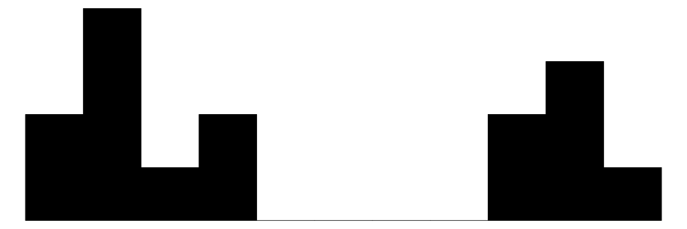

DIST

4

0

2.5

1.1

1.0

2.5

4.0

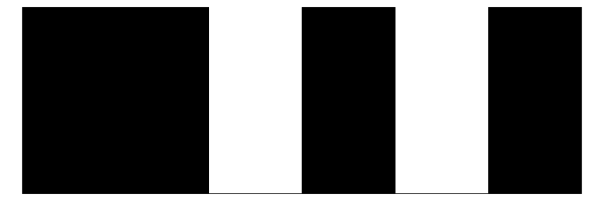

WORMS

36

0

8.0

4.3

0.0

8.8

17.8

[figure not shown]

COPPER

N

%

control

20

33.3

Week 1

20

33.3

Week 2

20

33.3

```r
copper |> modelsummary::datasummary_skim()
```

COPPER

DIST

Unique

Missing Pct.

Mean

SD

Min

Median

Max

Histogram

PLATE

control

4.0

5

0

97.6

84.2

34.0

39.0

200.0

control

3.0

5

0

97.6

84.2

34.0

39.0

200.0

control

2.0

5

0

97.6

84.2

34.0

39.0

200.0

control

1.0

5

0

97.6

84.2

34.0

39.0

200.0

Week 2

4.0

5

0

104.2

83.0

16.0

63.0

204.0

Week 2

3.0

5

0

104.2

83.0

16.0

63.0

204.0

Week 2

2.0

5

0

104.2

83.0

16.0

63.0

204.0

Week 2

1.0

5

0

104.2

83.0

16.0

63.0

204.0

Week 1

4.0

5

0

94.2

88.3

12.0

61.0

199.0

Week 1

3.0

5

0

94.2

88.3

12.0

61.0

199.0

Week 1

2.0

5

0

94.2

88.3

12.0

61.0

199.0

Week 1

1.0

5

0

94.2

88.3

12.0

61.0

199.0

WORMS

control

4.0

4

0

13.6

2.8

11.5

12.0

17.8

[figure not shown]

control

3.0

5

0

12.4

1.2

10.5

12.8

13.8

[figure not shown]

control

2.0

5

0

12.0

1.2

10.5

12.0

13.5

[figure not shown]

control

1.0

5

0

10.8

1.4

9.2

10.5

12.5

[figure not shown]

Week 2

4.0

4

0

7.8

1.0

6.5

8.0

8.8

[figure not shown]

Week 2

3.0

4

0

4.0

1.2

3.0

3.8

6.0

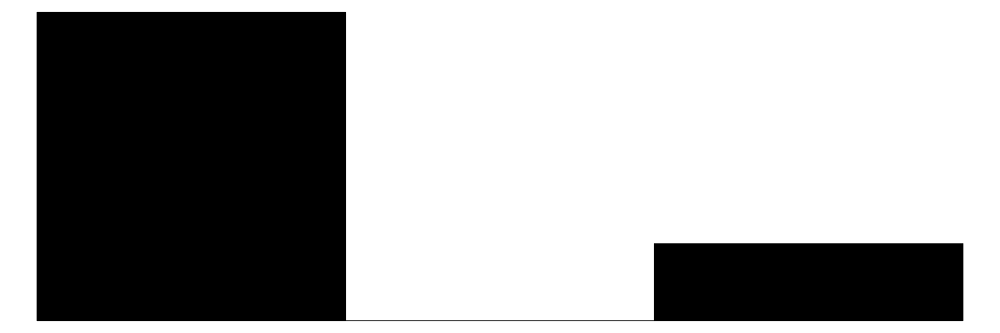

Week 2

2.0

5

0

1.4

1.0

0.5

1.0

3.0

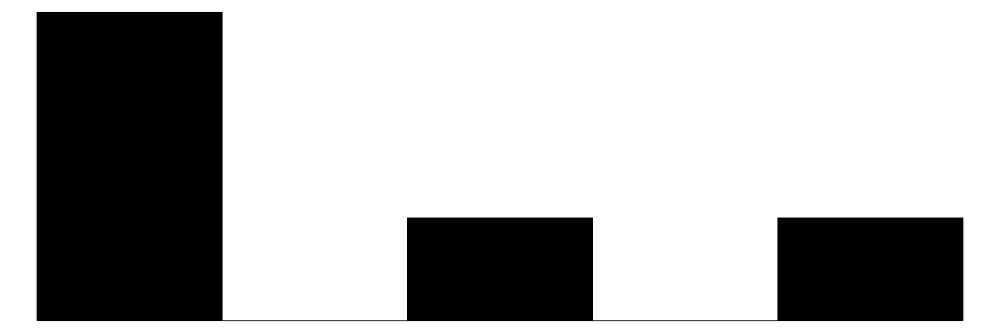

Week 2

1.0

3

0

0.2

0.4

0.0

0.0

1.0

[figure not shown]

Week 1

4.0

5

0

10.0

1.6

8.2

9.5

12.5

[figure not shown]

Week 1

3.0

5

0

8.5

1.5

7.0

8.2

10.8

[figure not shown]

Week 1

2.0

5

0

8.3

1.8

6.5

7.8

10.5

[figure not shown]

Week 1

1.0

5

0

7.2

1.2

6.2

6.8

9.2

[figure not shown]

COPPER

N

%

control

20

33.3

Week 1

20

33.3

Week 2

20

33.3

```r
copper |> modelsummary::datasummary_skim(by = c("COPPER", "DIST"))
```

# 4 Data preparation

Let start by declaring the categorical variables and random effect as factors.

```r
copper <- copper |> mutate(
  COPPER = factor(COPPER),
  PLATE = factor(PLATE),
  DIST = factor(DIST),
  AREA = 4,
  COUNT = WORMS * AREA
)
```

# 5 Exploratory data analysis

Model formula:
$$\begin{align}
y_i &\sim{} \mathcal{Pois}(\lambda_i)\\
ln(\lambda_i) &=\boldsymbol{\beta} \bf{X_i} + \boldsymbol{\gamma} \bf{Z_i}
\end{align}$$

where $\boldsymbol{\beta}$ and $\boldsymbol{\gamma}$ are vectors of the fixed and random effects parameters respectively and $\bf{X}$ is the model matrix representing the overall intercept and effects of copper, distance and their interaction on the number of number of worms. Area of the place segment was also incorporated as an offset. $\bf{Z}$ represents a cell means model matrix for the random intercepts associated with individual plates.

These data are density of worms. This is not ideal. It would be better to have the actual counts along with the area and then model against a Poisson or Negative Binomial along with having an offset for area. Such an approach would allow us to effectively model density whilst also being able to fit a model with a distribution that closely matches the data generation process.

Unfortunately, we only have the densities. As such, our choice of model families is somewhat restricted. Out choices are:

- Gaussian: assuming normality etc
- log-normal:
- Gamma with a log link: so long as we can address the presence of zeros in the data
- Tweedie

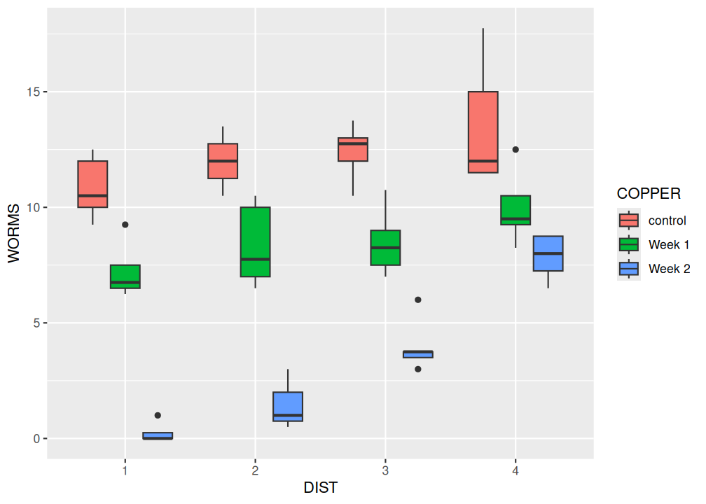

```r
ggplot(copper, aes(y = WORMS, x = DIST, fill = COPPER)) +
  geom_boxplot()
```

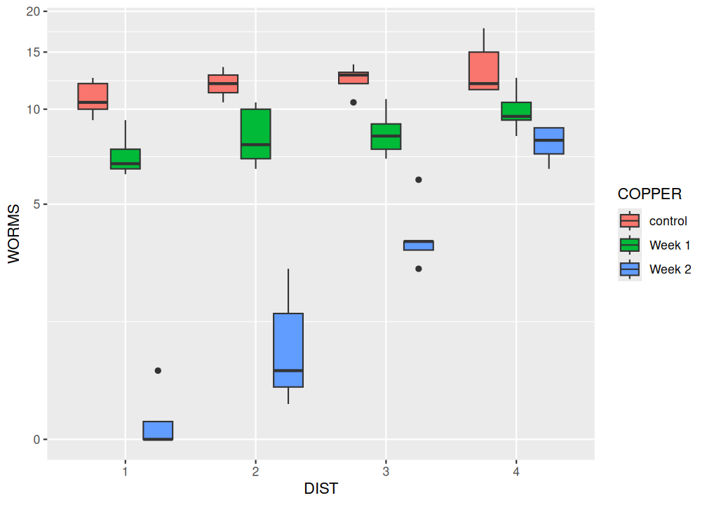

```r
ggplot(copper, aes(y = WORMS, x = DIST, fill = COPPER)) +
  geom_boxplot() +
  scale_y_continuous(trans = scales::pseudo_log_trans())
```

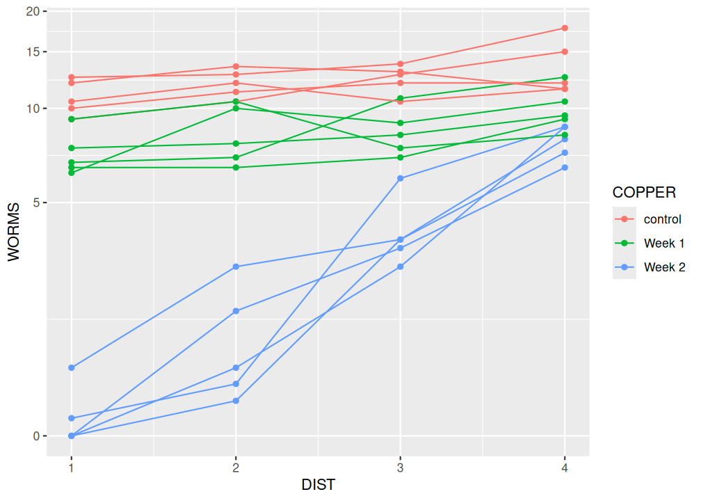

```r
ggplot(copper, aes(y = WORMS, x = DIST, colour = COPPER)) +
  geom_point(aes(x = as.numeric(DIST))) +
  geom_line(aes(x = as.numeric(DIST), group = PLATE)) +
  scale_y_continuous(trans = scales::pseudo_log_trans())
```

In the event that we attempt to model these data against a Gamma family, we are going to need a way to handle the zero values. A Gamma distribution has no mass at zero. One solution is to replace the zero values with small values, where small value is defined as half the value of the smallest positive value.

```r
copper |>
  filter(WORMS > 0) |>
  summarise(min(WORMS) / 2)
```

```
# A tibble: 1 × 1
  `min(WORMS)/2`
           <dbl>
1          0.125
```

# 6 Fit the model

**brms**

**Using default priors**

In `brms`, the default priors are designed to be weakly informative. They are chosen to provide moderate regularisation (to help prevent over fitting) and help stabilise the computations.

Unlike `rstanarm`, `brms` models must be compiled before they start sampling. For most models, the compilation of the stan code takes around 45 seconds.

```r
copper.form <- bf(WORMS ~ COPPER * DIST + (1|PLATE),
                family=Gamma(link='log'))
options(width=150)
copper.form |> get_prior(data = copper)
```

```
                  prior     class              coef group resp dpar nlpar lb ub       source
                 (flat)         b                                                    default
                 (flat)         b       COPPERWeek1                             (vectorized)
                 (flat)         b COPPERWeek1:DIST2                             (vectorized)
                 (flat)         b COPPERWeek1:DIST3                             (vectorized)
                 (flat)         b COPPERWeek1:DIST4                             (vectorized)
                 (flat)         b       COPPERWeek2                             (vectorized)
                 (flat)         b COPPERWeek2:DIST2                             (vectorized)
                 (flat)         b COPPERWeek2:DIST3                             (vectorized)
                 (flat)         b COPPERWeek2:DIST4                             (vectorized)
                 (flat)         b             DIST2                             (vectorized)
                 (flat)         b             DIST3                             (vectorized)
                 (flat)         b             DIST4                             (vectorized)
 student_t(3, 2.2, 2.5) Intercept                                                    default
   student_t(3, 0, 2.5)        sd                                          0         default
   student_t(3, 0, 2.5)        sd                   PLATE                  0    (vectorized)
   student_t(3, 0, 2.5)        sd         Intercept PLATE                  0    (vectorized)
      gamma(0.01, 0.01)     shape                                          0         default
```

```r
options(width=80)
```

**Defining priors**

The following link provides some guidance about defining priors. [https://github.com/stan-dev/stan/wiki/Prior-Choice-Recommendations]

When defining our own priors, we typically do not want them to be scaled.

If we wanted to define our own priors that were less vague, yet still not likely to bias the outcomes, we could try the following priors (mainly plucked out of thin air):

- $\beta_0$: normal centred at 3 with a standard deviation of 0.45
  - mean of 3: since `median(log(copper$WORMS+10.125))` or `median(asinh(copper$WORMS/(2*1))/log(exp(1)))`
  - sd of 0.45: since `mad(log(copper$WORMS+0.125))` or `mad(asinh(copper$WORMS/(2*1))/log(exp(1)))`
- $\beta_{1-2}$: normal centred at 0 with a standard deviation of 0.9
  - sd of 0.9: since `mad(log(copper$WORMS+0.125))/model.matrix(~COPPER*DIST, data = copper) |> apply(2, sd)`
- $\beta_{3-5}$: normal centred at 0 with a standard deviation of 1
  - sd of 1: since `mad(log(copper$WORMS+0.125))/model.matrix(~COPPER*DIST, data = copper) |> apply(2, sd)`
- $\beta_{6-11}$: normal centred at 0 with a standard deviation of 1.5
  - sd of 1.5: since `mad(log(copper$WORMS+0.125))/model.matrix(~COPPER*DIST, data = copper) |> apply(2, sd)`
- $\sigma_j$: half-cauchy with parameters 0 and 2.
- $\omega$: gamma with parameters 0.01 and 0.01.
- $\Sigma$: decov with:
  - regularisation: the exponent for a LKJ prior on the correlation matrix. A value of 1 (default) implies a joint uniform prior
  - concentration: the concentration parameter for a symmetric Dirichlet distribution. A value of 1 (default) implies a joint uniform distribution
  - shape and scale: the shape and scale parameters for a gamma prior on the scale and scale parameters of the decov prior. A value of 1 for both (default) simplifies the gamma prior to a unit-exponential distribution.

```r
copper |>
  group_by(COPPER, DIST) |>
  summarise(
    log(median(WORMS)),
    log(mad(WORMS))
  )
```

```
# A tibble: 12 × 4
# Groups:   COPPER [3]
   COPPER  DIST  `log(median(WORMS))` `log(mad(WORMS))`
   <fct>   <fct>                <dbl>             <dbl>
 1 control 1                     2.35             0.617
 2 control 2                     2.48             0.106
 3 control 3                     2.55             0.106
 4 control 4                     2.48            -0.299
 5 Week 1  1                     1.91            -0.299
 6 Week 1  2                     2.05             0.617
 7 Week 1  3                     2.11             0.106
 8 Week 1  4                     2.25             0.394
 9 Week 2  1                  -Inf             -Inf
10 Week 2  2                     0               -0.299
11 Week 2  3                     1.32            -0.992
12 Week 2  4                     2.08             0.106
```

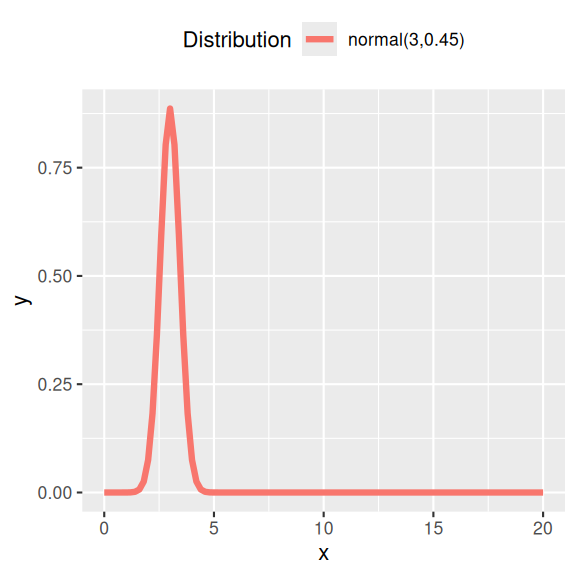

```r
standist::visualize("normal(3,0.45)", xlim = c(0, 20))
```

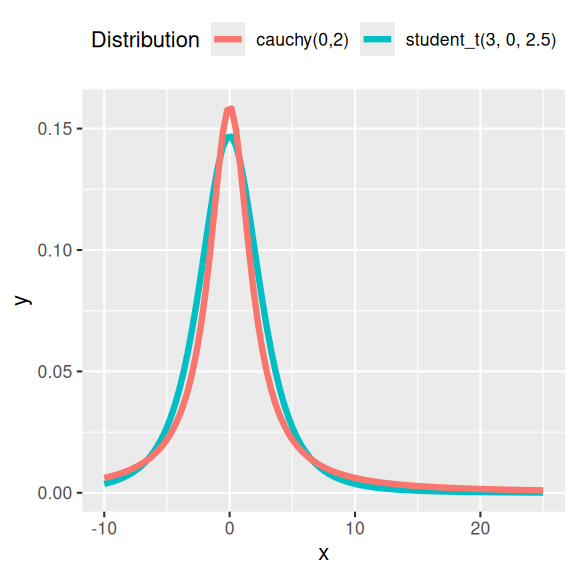

```r
standist::visualize("student_t(3, 0, 2.5)",
  "cauchy(0,2)",
  xlim = c(-10, 25)
)
```

**Poisson with an offset**

```r
priors <- prior(normal(2.5, 0.6), class = "Intercept") +
  prior(normal(0, 1.5), class = "b") +
  prior(student_t(3, 0, 1), class = "sd")

copper.form <- bf(COUNT ~ offset(log(AREA)) + COPPER * DIST + (1 | PLATE),
  family = poisson(link = "log")
)
copper.brm2 <- brm(copper.form,
  data = copper,
  prior = priors,
  sample_prior = "only",
  iter = 5000,
  warmup = 2500,
  chains = 3,
  cores = 3,
  thin = 10,
  refresh = 0,
  seed = 123,
  control = list(adapt_delta = 0.99)
)
```

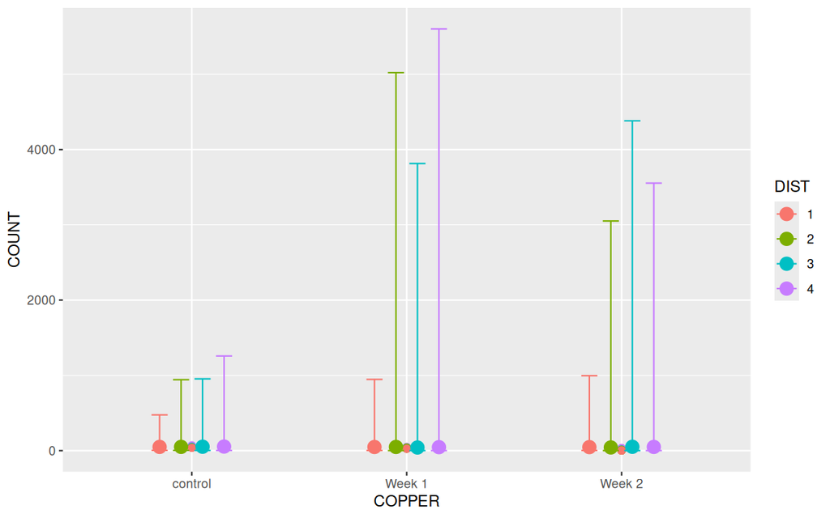

```r
copper.brm2 |>
  conditional_effects("COPPER:DIST") |>
  plot(points = TRUE)
```

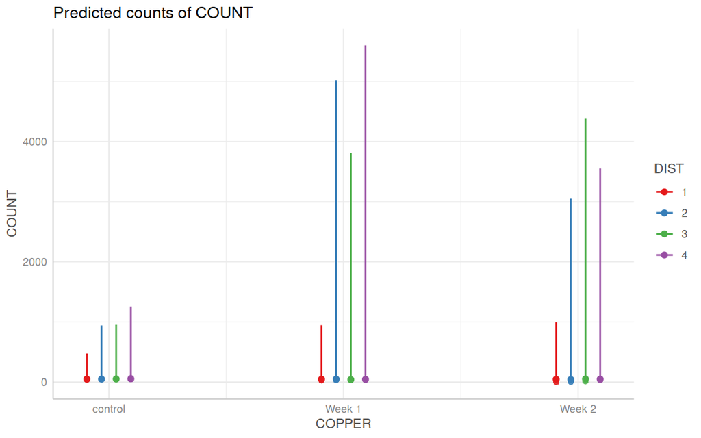

```r
copper.brm2 |>
  ggpredict(~ COPPER * DIST) |>
  plot(show_data = TRUE)
```

The above seem sufficiently wide whilst at the same time not providing any encouragement for the sampler to wander off into very unsupported areas.

```r
copper.brm3 <- update(copper.brm2,
  sample_prior = "yes",
  control = list(adapt_delta = 0.99),
  refresh = 0
)
```

```
The desired updates require recompiling the model
```

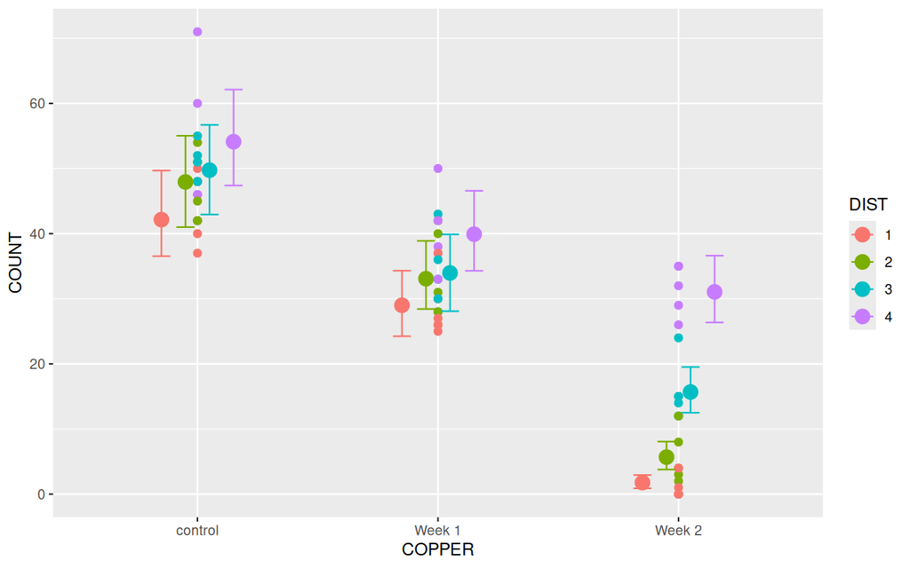

```r
copper.brm3 |>
  conditional_effects("COPPER:DIST") |>
  plot(points = TRUE)
```

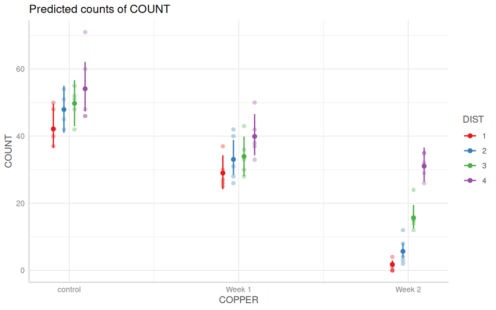

```r
copper.brm3 |>
  ggpredict(~ COPPER * DIST) |>
  plot(show_data = TRUE)
```

**log-normal**

```r
priors <- prior(normal(3, 0.45), class = "Intercept") +
  prior(normal(0, 0.9), class = "b", coef = "COPPERWeek1") +
  prior(normal(0, 0.9), class = "b", coef = "COPPERWeek2") +
  prior(normal(0, 1), class = "b", coef = "DIST2") +
  prior(normal(0, 1), class = "b", coef = "DIST3") +
  prior(normal(0, 1), class = "b", coef = "DIST4") +
  prior(normal(0, 1.5), class = "b") +
  prior(cauchy(0, 2), class = "sd") +
  prior(gamma(2, 1), class = "sigma")

copper.form <- bf(I(WORMS + 0.125) ~ COPPER * DIST + (1 | PLATE),
  family = lognormal()
)
copper.brm2a <- brm(copper.form,
  data = copper,
  prior = priors,
  sample_prior = "only",
  iter = 5000,
  warmup = 2500,
  chains = 3,
  cores = 3,
  thin = 10,
  refresh = 0,
  seed = 123,
  control = list(adapt_delta = 0.99)
)
```

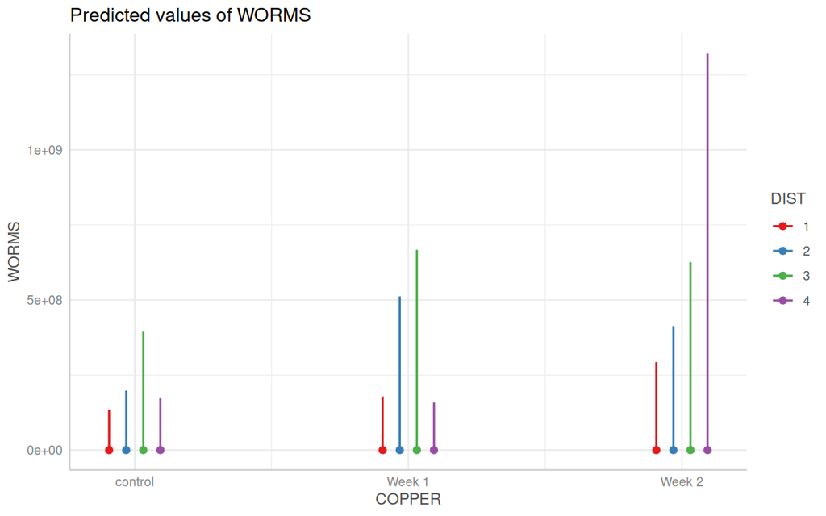

```r
copper.brm2a |>
  ggpredict(~ COPPER * DIST) |>
  plot(show_data = TRUE)
```

The above seem sufficiently wide whilst at the same time not providing any encouragement for the sampler to wander off into very unsupported areas.

```r
copper.brm3a <- update(copper.brm2a,
  sample_prior = "yes",
  control = list(adapt_delta = 0.99),
  refresh = 0
)
```

```
The desired updates require recompiling the model
```

**Gamma**

```r
priors <- prior(normal(3, 0.45), class = "Intercept") +
  prior(normal(0, 0.9), class = "b", coef = "COPPERWeek1") +
  prior(normal(0, 0.9), class = "b", coef = "COPPERWeek2") +
  prior(normal(0, 1), class = "b", coef = "DIST2") +
  prior(normal(0, 1), class = "b", coef = "DIST3") +
  prior(normal(0, 1), class = "b", coef = "DIST4") +
  prior(normal(0, 1.5), class = "b") +
  prior(cauchy(0, 1), class = "sd") +
  prior(gamma(0.01, 0.01), class = "shape")

copper.form <- bf(I(WORMS + 0.125) ~ COPPER * DIST + (DIST | PLATE),
  family = Gamma(link = "log")
)
copper.brm2b <- brm(copper.form,
  data = copper,
  prior = priors,
  sample_prior = "only",
  iter = 5000,
  warmup = 2500,
  chains = 3,
  cores = 3,
  thin = 10,
  refresh = 0,
  seed = 123,
  control = list(adapt_delta = 0.99)
)
```

```r
copper.brm3b <- update(copper.brm2b,
  sample_prior = "yes",
  control = list(adapt_delta = 0.99),
  refresh = 0
)
```

```
The desired updates require recompiling the model
```

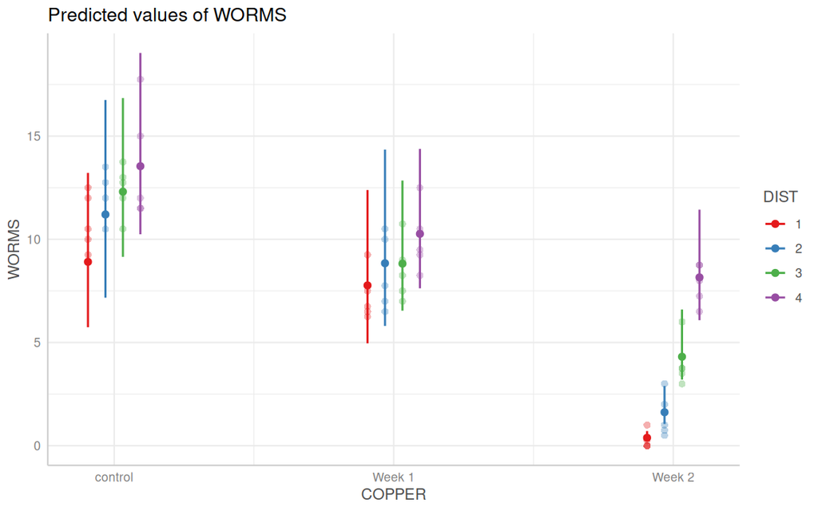

```r
copper.brm3b |>
  ggpredict(~ COPPER * DIST) |>
  plot(show_data = TRUE)
```

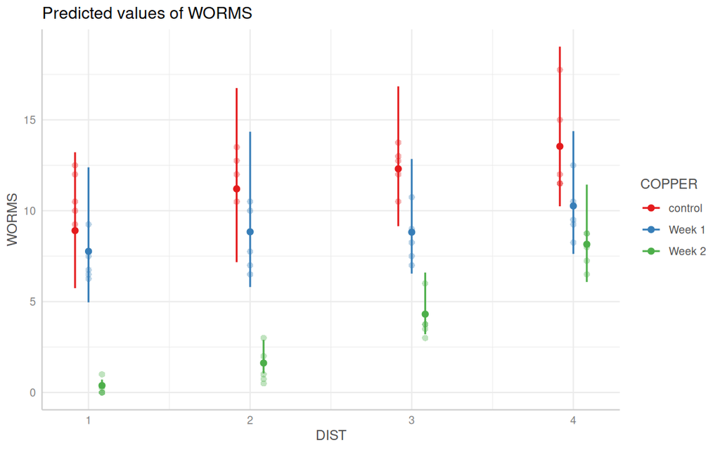

```r
copper.brm3b |>
  ggpredict(~ DIST * COPPER) |>
  plot(show_data = TRUE)
```

**Plotting prior and posterior**

**Poisson with offset**

```r
copper.brm3 |> get_variables()
```

```
 [1] "b_Intercept"            "b_COPPERWeek1"          "b_COPPERWeek2"
 [4] "b_DIST2"                "b_DIST3"                "b_DIST4"
 [7] "b_COPPERWeek1:DIST2"    "b_COPPERWeek2:DIST2"    "b_COPPERWeek1:DIST3"
[10] "b_COPPERWeek2:DIST3"    "b_COPPERWeek1:DIST4"    "b_COPPERWeek2:DIST4"
[13] "sd_PLATE__Intercept"    "Intercept"              "r_PLATE[12,Intercept]"
[16] "r_PLATE[16,Intercept]"  "r_PLATE[21,Intercept]"  "r_PLATE[34,Intercept]"
[19] "r_PLATE[36,Intercept]"  "r_PLATE[39,Intercept]"  "r_PLATE[57,Intercept]"
[22] "r_PLATE[61,Intercept]"  "r_PLATE[63,Intercept]"  "r_PLATE[178,Intercept]"
[25] "r_PLATE[179,Intercept]" "r_PLATE[181,Intercept]" "r_PLATE[199,Intercept]"
[28] "r_PLATE[200,Intercept]" "r_PLATE[204,Intercept]" "prior_Intercept"
[31] "prior_b"                "prior_sd_PLATE"         "lprior"
[34] "lp__"                   "accept_stat__"          "stepsize__"
[37] "treedepth__"            "n_leapfrog__"           "divergent__"
[40] "energy__"
```